# R tutorial summary

#### Boxplots

We can use boxplots to display the relationship of a categorical variable and a numeric variable.

Boxplot can be used to show the distribution of a numeric data set in some sense.

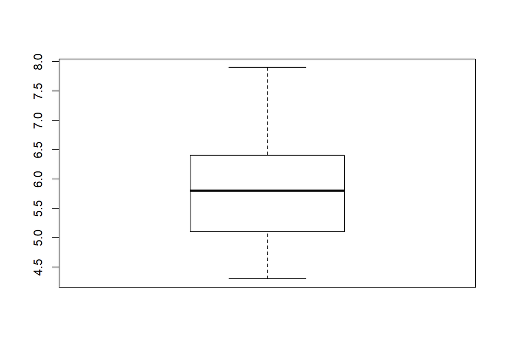

```r
boxplot(data$Sepal.Length)
```

The boxplot can also reflect the data of different classes simultaneously.

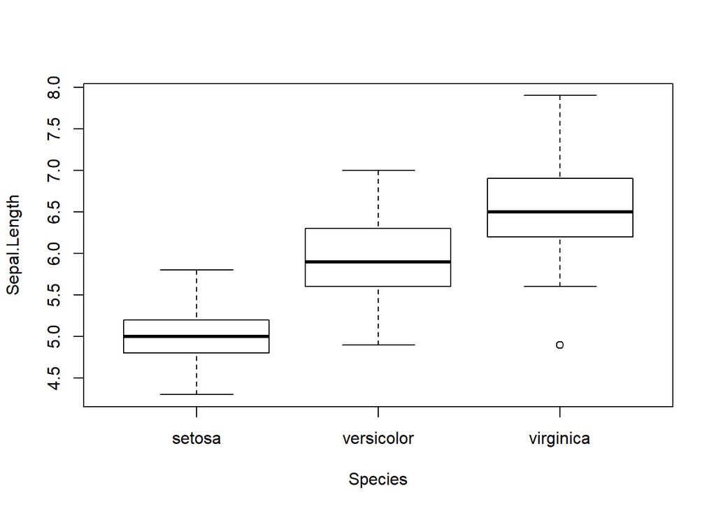

```r
boxplot(Sepal.Length ~ Species, data = data)
```

The x axis is classified by the species, and boxplot of the Sepal.Length of each sepicies are laid in order. Inputting more parameters can refine the boxplot. The following is an example:

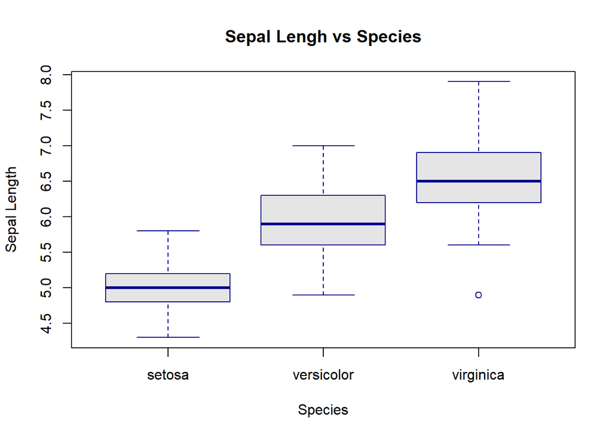

```r
boxplot(Sepal.Length ~ Species, data = data,
     xlab   = "Species", #the name of x axis
     ylab   = "Sepal Length", #the name of y axis
     main   = "Sepal Lengh vs Species", #the title of the boxplot
     col    = "grey90", #the color of the fillings in the box
     border = "darkblue") #the color of the border of the boxplot
```

#### Scatterplots

If only the data of one variable is input, the x axis will be the index of each data point automatically.

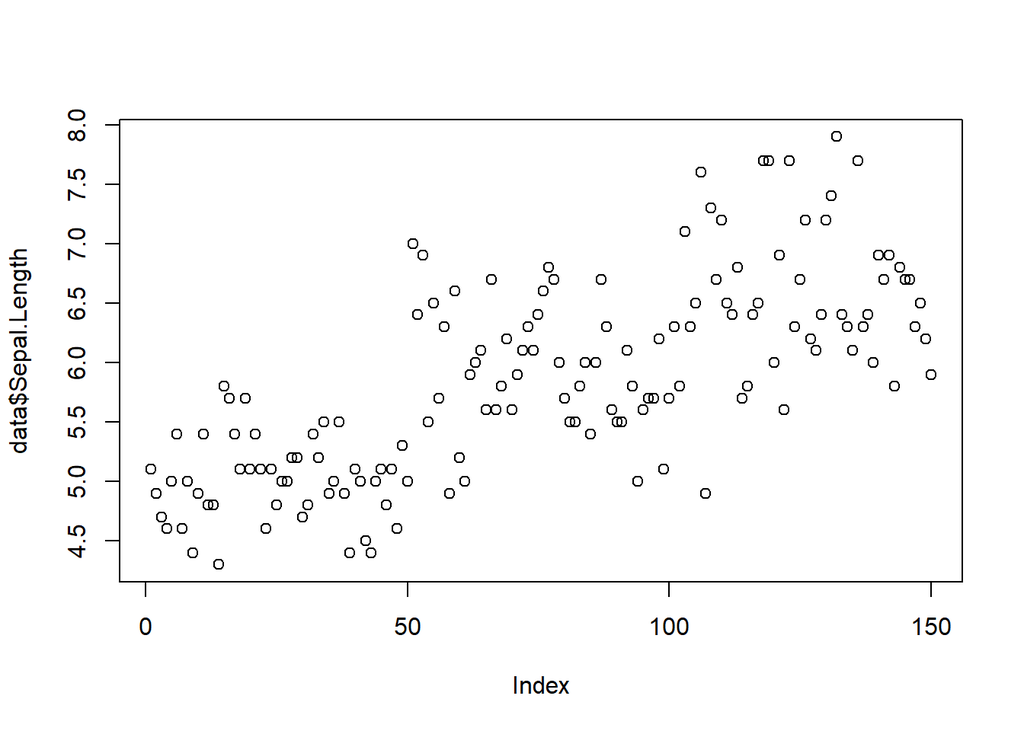

```r
plot(data$Sepal.Length)
```

Scatterplot can also reflect the relationship of two variables. In the following example, the x and y coordinates of each point represent its sepal width and sepal length respectively.

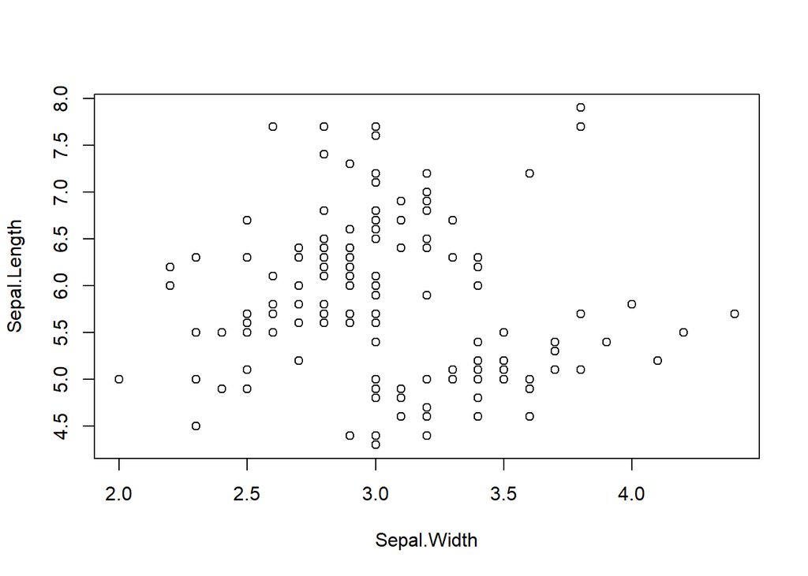

```r
plot(Sepal.Length ~ Sepal.Width, data = data)
```

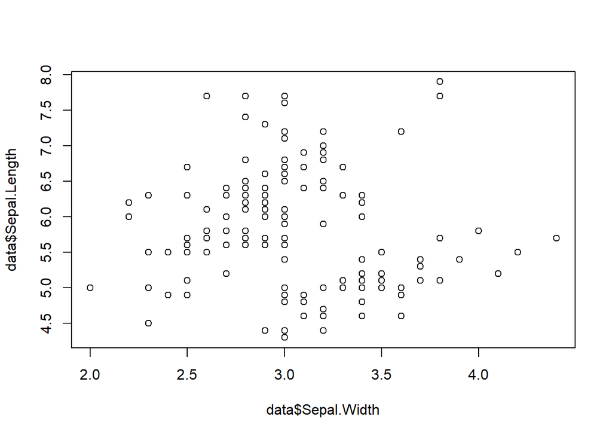

```r
plot(data$Sepal.Width, data$Sepal.Length)
```

```r
#The two ways above are equivalent.
```

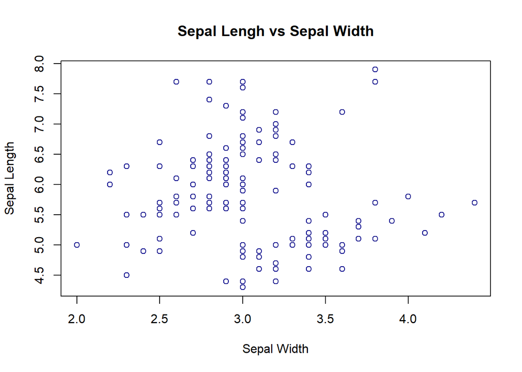

```r
plot(Sepal.Length ~ Sepal.Width, data = data,
     xlab   = "Sepal Width", #the name of x axis
     ylab   = "Sepal Length", #the name of y axis
     main   = "Sepal Lengh vs Sepal Width", #the title of the plot
     col    = "darkblue") #the color of the points
```

#### Line plots

In the “plot” function, setting the parameter “type” as “l” helps return a line plot.

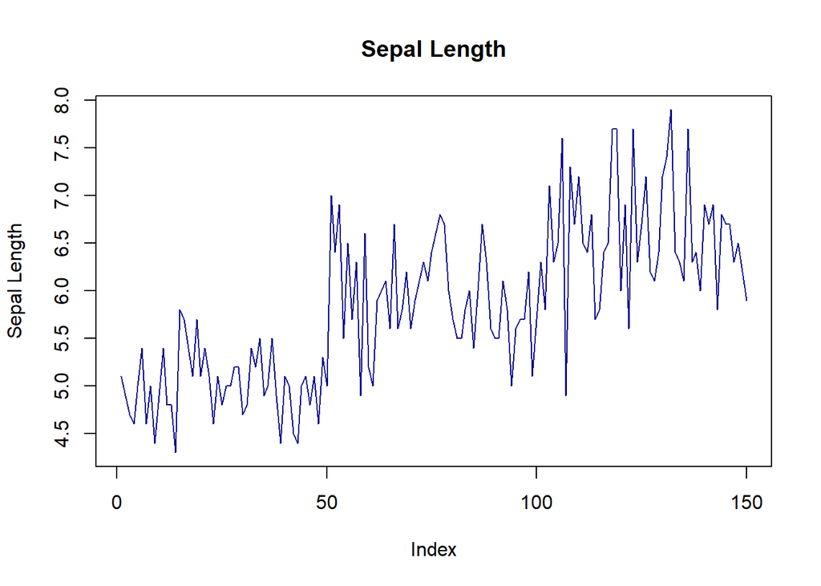

```r
plot(data$Sepal.Length, #the data
     type = "l", #the type of the plot is line plot
     col = "darkblue", #the color of the line
     lwd = 1, #the width of the line
     lty = 1, #the type of the line
     ylab = "Sepal Length", #the name of y axis
     main = "Sepal Length") #the title of the line plot
```

Different lines can be added on one plot.

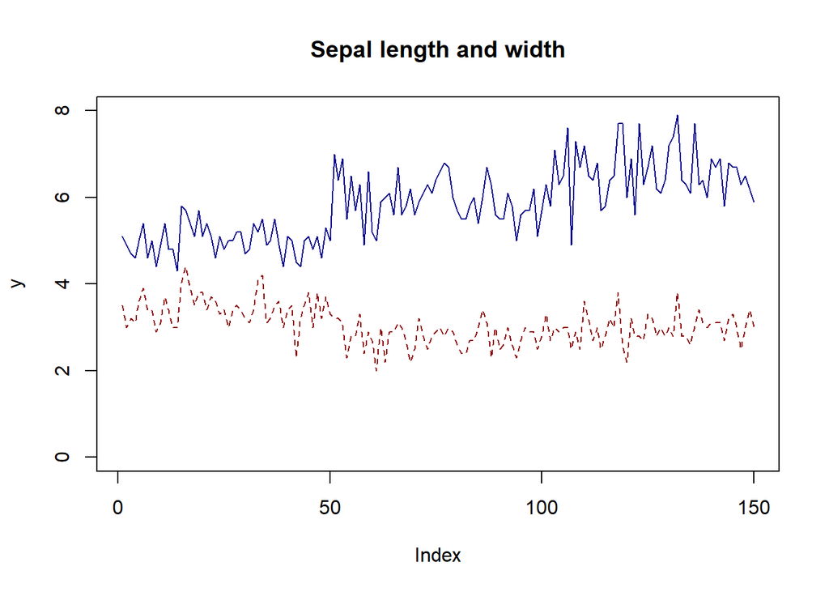

```r
plot(data$Sepal.Length, #the data
     type = "l", #the type of the plot is line plot
     col = "darkblue", #the color of the line
     lwd = 1, #the width of the line
     lty = 1, #the type of the line
     ylim = c(0, 8),
     ylab = "y", #the name of y axis
     main = "Sepal length and width") #the title of the line plot
lines(data$Sepal.Width,
      col = "darkred",
      lwd = 1,
      lty = 2)
```

Legend is often used to distinguish different lines.

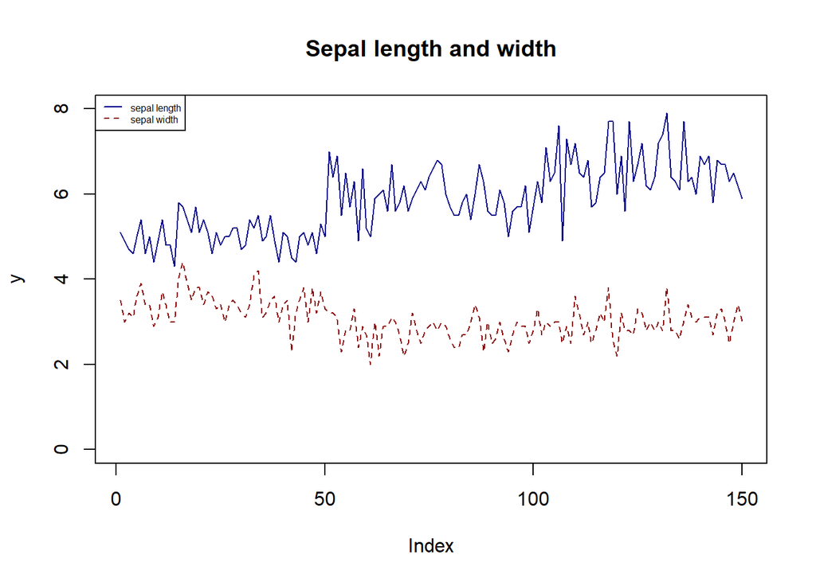

```r
plot(data$Sepal.Length, #the data
     type = "l", #the type of the plot is line plot
     col = "darkblue", #the color of the line
     lwd = 1, #the width of the line
     lty = 1, #the type of the line
     ylim = c(0, 8),
     ylab = "y", #the name of y axis
     main = "Sepal length and width") #the title of the line plot
lines(data$Sepal.Width,
      col = "darkred",
      lwd = 1,
      lty = 2)
legend("topleft", #the location of the legend
       legend = c("sepal length", "sepal width"), #the variables corresponding to all lines
       col = c("darkblue", "darkred"), #the color of the lines
       lty = c(1,2), #the type of the lines
       cex = 0.5) #the size of the legend box
```

## Reference

[1] Alan Agresti. *Foundations of linear and generalized linear models.* John Wiley & Sons, 2015.